# Prediction of flight delays

### Feature engineering

#### Features setup

Convert DEP_TIME and ARR_TIME to occasions.

```r
convert_to_hour <- function(time) {
  if (is.na(time) || time == "") return(NA)
  time <- sprintf("%04d", time)
  return(as.numeric(substr(time, 1, 2)))
}

get_occasion <- function(hour) {
  if (is.na(hour)) return(NA)
    case_when(
    hour >= 5 & hour < 8 ~ "Early Morning",
    hour >= 8 & hour < 12 ~ "Late Morning",
    hour >= 12 & hour < 15 ~ "Early Afternoon",
    hour >= 15 & hour < 18 ~ "Late Afternoon",
    hour >= 18 & hour < 21 ~ "Evening",
    TRUE ~ "Night"
  )
}

light_filtered_flight_data = filtered_flight_data %>% sample_n(2e5)

light_filtered_flight_data <- light_filtered_flight_data %>%
  mutate(
    DEP_TIME_converted = sapply(DEP_TIME, convert_to_hour),
    ARR_TIME_converted = sapply(ARR_TIME, convert_to_hour),
    departure_occasion = sapply(DEP_TIME_converted, get_occasion),
    arrival_occasion = sapply(ARR_TIME_converted, get_occasion)
  ) %>%
  select(-DEP_TIME_converted, -ARR_TIME_converted)
```

Convert FL_DATE into is_weekend and occasions.

```r
light_filtered_flight_data <- light_filtered_flight_data %>%
  mutate(FL_DATE = ymd(FL_DATE))

light_filtered_flight_data <- light_filtered_flight_data %>%
  mutate(is_weekend = wday(FL_DATE) %in% c(1, 7))

light_filtered_flight_data <- light_filtered_flight_data %>%
  mutate(season = case_when(
    (month(FL_DATE) == 12 & day(FL_DATE) >= 20) |
    (month(FL_DATE) == 1 & day(FL_DATE) <= 5) ~ "christmas_new_year",
    (month(FL_DATE) >= 6 & month(FL_DATE) <= 8) ~ "summer_holidays",
    TRUE ~ "other"
  ))
```

#### Features filtering

Selecting preliminary features based on domain knowledge

```r
training_flight_data <- light_filtered_flight_data %>%
  select(
      AIRLINE_CODE,
      ORIGIN,
      DEST,
      TAXI_IN,
      TAXI_OUT,
      AIR_TIME,
      DISTANCE,
      is_weekend,
      season,
      departure_occasion,
      arrival_occasion,
      is_delayed
)
```

Checking for missing values

```r
missing_summary <- training_flight_data %>%
  summarise_all(~ sum(is.na(.))) %>%
  gather(key = "column", value = "missing_count") %>%
  mutate(
    total_count = nrow(training_flight_data),
    missing_percent = (missing_count / total_count) * 100
  ) %>%
  select(column, missing_count, missing_percent)

print(missing_summary)
```

```
##                column missing_count missing_percent
## 1        AIRLINE_CODE             0               0
## 2              ORIGIN             0               0
## 3                DEST             0               0
## 4             TAXI_IN             0               0
## 5            TAXI_OUT             0               0
## 6            AIR_TIME             0               0
## 7            DISTANCE             0               0
## 8          is_weekend             0               0
## 9              season             0               0
## 10 departure_occasion             0               0
## 11   arrival_occasion             0               0
## 12         is_delayed             0               0
```

Checking for 6-sigma outliers in distance, taxi times and distance

```r
calculate_outliers <- function(x) {
  mu <- mean(x, na.rm = TRUE)
  sigma <- sd(x, na.rm = TRUE)
  outliers <- sum(x < (mu - 6 * sigma) | x > (mu + 6 * sigma), na.rm = TRUE)
  return(outliers)
}

outliers_summary <- training_flight_data %>%
  summarise(
    distance_outliers = calculate_outliers(DISTANCE),
    air_time_outliers = calculate_outliers(AIR_TIME),
    taxi_in_outliers = calculate_outliers(TAXI_IN),
    taxi_out_outliers = calculate_outliers(TAXI_OUT)
  ) %>%
  gather(key = "column", value = "outliers_count") %>%
  mutate(
    total_count = nrow(training_flight_data),
    outliers_percent = (outliers_count / total_count) * 100
  ) %>%
  select(column, outliers_count, outliers_percent)

print(outliers_summary)
```

```
##              column outliers_count outliers_percent
## 1 distance_outliers             89           0.0445
## 2 air_time_outliers             67           0.0335
## 3  taxi_in_outliers            660           0.3300
## 4 taxi_out_outliers            580           0.2900
```

Drop of 6-sigma outliers

```r
means_sds <- training_flight_data %>%
  summarise(
    mean_distance = mean(DISTANCE, na.rm = TRUE),
    sd_distance = sd(DISTANCE, na.rm = TRUE),
    mean_taxi_in = mean(TAXI_IN, na.rm = TRUE),
    sd_taxi_in = sd(TAXI_IN, na.rm = TRUE),
    mean_taxi_out = mean(TAXI_OUT, na.rm = TRUE),
    sd_taxi_out = sd(TAXI_OUT, na.rm = TRUE),
    mean_air_time = mean(AIR_TIME, na.rm = TRUE),
    sd_air_time = sd(AIR_TIME, na.rm = TRUE)
  )

is_6sigma_outlier <- function(x, mean, sd) {
  abs(x - mean) > 6 * sd
}

training_flight_data <- training_flight_data %>%
  filter(
    !is_6sigma_outlier(DISTANCE, means_sds$mean_distance, means_sds$sd_distance) &
    !is_6sigma_outlier(TAXI_IN, means_sds$mean_taxi_in, means_sds$sd_taxi_in) &
    !is_6sigma_outlier(TAXI_OUT, means_sds$mean_taxi_out, means_sds$sd_taxi_out) &
    !is_6sigma_outlier(AIR_TIME, means_sds$sd_air_time, means_sds$sd_air_time)
  )
```

#### Features correlations

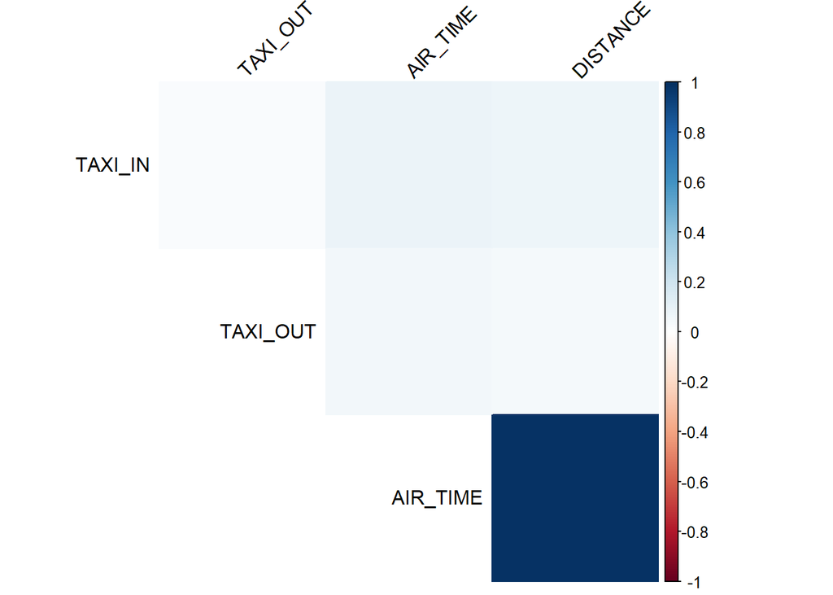

```r
numeric_columns <- select_if(training_flight_data, is.numeric)
correlation_matrix <- cor(numeric_columns, use = "pairwise.complete.obs")
corrplot(correlation_matrix, method = "color", type = "upper",
         tl.col = "black", tl.srt = 45, diag = FALSE)
```

#### New features analysis

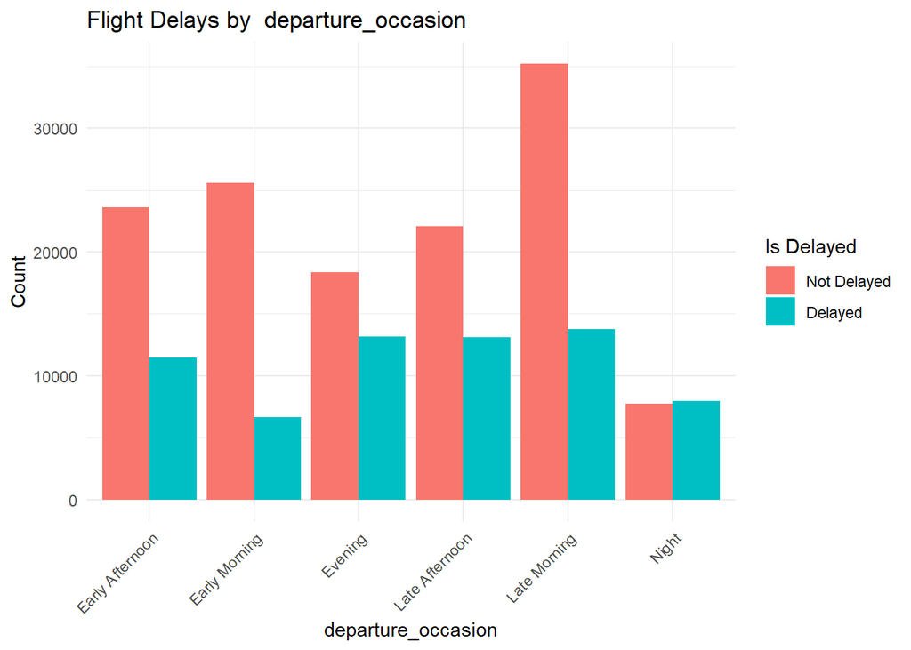

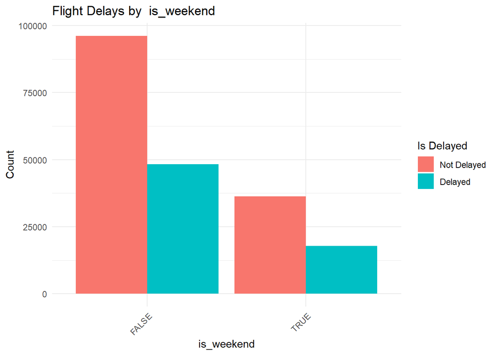

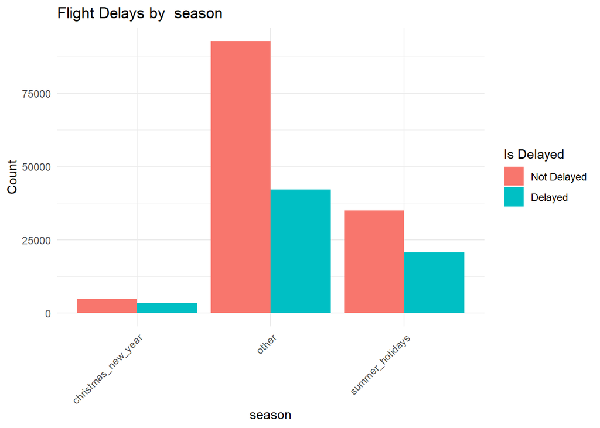

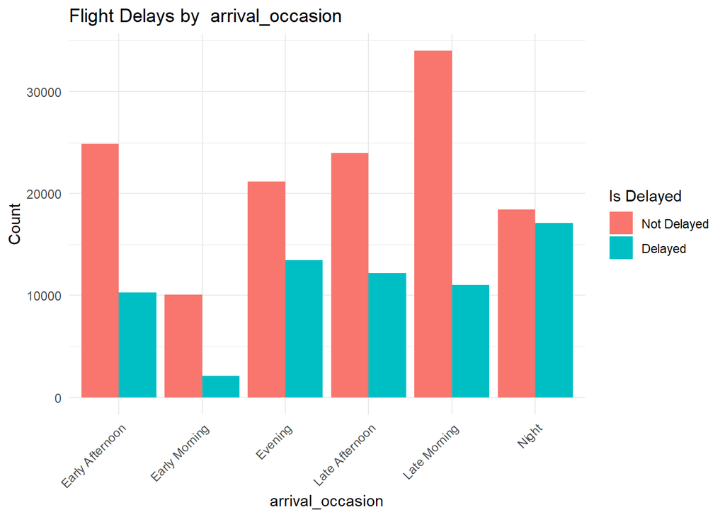

```r
features <- c("departure_occasion", "is_weekend", "season", "arrival_occasion")
plots <- list()
for (feature in features) {
  summarised_feature <- training_flight_data %>%
      group_by(is_delayed, .data[[feature]]) %>%
      summarise(count  = n())
  summarised_feature$is_delayed <- factor(summarised_feature$is_delayed,
                                          levels = c(FALSE, TRUE),
                                          labels = c("Not Delayed", "Delayed"))

  plot <- ggplot(summarised_feature, aes(x = .data[[feature]], y = count, fill = is_delayed)) +
    geom_bar(stat = "identity", position = "dodge") +
    labs(title = paste("Flight Delays by ", feature),
         x = feature,
         y = "Count",
         fill = "Is Delayed") +
    theme_minimal() +
    theme(axis.text.x = element_text(angle = 45, hjust = 1))

  plots[[feature]] <- plot
}

for (feature in features) {
  print(plots[[feature]])
}
```

#### Features encoding

```r
training_flight_data_encoded <- training_flight_data
columns_to_encode <- c("AIRLINE_CODE", "ORIGIN", "DEST", "is_weekend",
                       "season", "departure_occasion", "arrival_occasion")

for (col in columns_to_encode) {
  training_flight_data_encoded[[col]] <- factor(training_flight_data_encoded[[col]])
  training_flight_data_encoded[[col]] <- as.numeric(factor(training_flight_data_encoded[[col]]))
}
```

### Machine Learning classification

#### Preparing train and test datasets

```r
set.seed(123)
y <- ifelse(training_flight_data_encoded$is_delayed,"True","False")
X <- training_flight_data_encoded[, !names(training_flight_data_encoded) %in% c("is_delayed")]
train_indices <- sample(nrow(training_flight_data_encoded), 0.7 * nrow(training_flight_data_encoded))
X_train <- X[train_indices, ]
X_test <- X[-train_indices, ]
y_train <- y[train_indices]
y_test <- y[-train_indices]
```

#### Using Logistic Regression

Cross-validation and the tuning grid

```r
ctrl <- trainControl(method = "cv",
                     number = 10,
                     summaryFunction = twoClassSummary,
                     classProbs = TRUE,
                     verboseIter = TRUE)

grid <- expand.grid(alpha = 0:1,
                    lambda = seq(0.001, 0.1, by = 0.001))
```

Training

```r
set.seed(123)
logit_model <- train(x = X_train,
                     y = y_train,
                     method = "glmnet",
                     trControl = ctrl,
                     tuneGrid = grid,
                     metric = "ROC",
                     family = "binomial",
                     type.measure = "ROC")
```

Predictions and performance

```r
print(logit_model)
```

```
## glmnet
##
## 139052 samples
##     11 predictor
##      2 classes: 'False', 'True'
##
## No pre-processing
## Resampling: Cross-Validated (10 fold)
## Summary of sample sizes: 125146, 125147, 125147, 125148, 125146, 125147, ...
## Resampling results across tuning parameters:
##
##   alpha  lambda  ROC        Sens       Spec
##   0      0.001   0.6886244  0.9408327  0.26973991
##   0      0.002   0.6886244  0.9408327  0.26973991
##   0      0.003   0.6886244  0.9408327  0.26973991
```

[output cut: 200 more lines]

Confusion Matrix

```r
predictions <- predict(logit_model, newdata = X_test)
y_test <- factor(y_test, levels = levels(predictions))
confusionMatrix(predictions, y_test)
```

```
## Confusion Matrix and Statistics
##
##           Reference
## Prediction False  True
##      False 36947 13612
##      True   2827  6209
##
##                Accuracy : 0.7242
##                  95% CI : (0.7205, 0.7277)
##     No Information Rate : 0.6674
##     P-Value [Acc > NIR] : < 2.2e-16
##
##                   Kappa : 0.2805
##
##  Mcnemar's Test P-Value : < 2.2e-16
##
##             Sensitivity : 0.9289
##             Specificity : 0.3133
##          Pos Pred Value : 0.7308
##          Neg Pred Value : 0.6871
##              Prevalence : 0.6674
##          Detection Rate : 0.6200
##    Detection Prevalence : 0.8484
##       Balanced Accuracy : 0.6211
##
##        'Positive' Class : False
##
```

ROC Curve

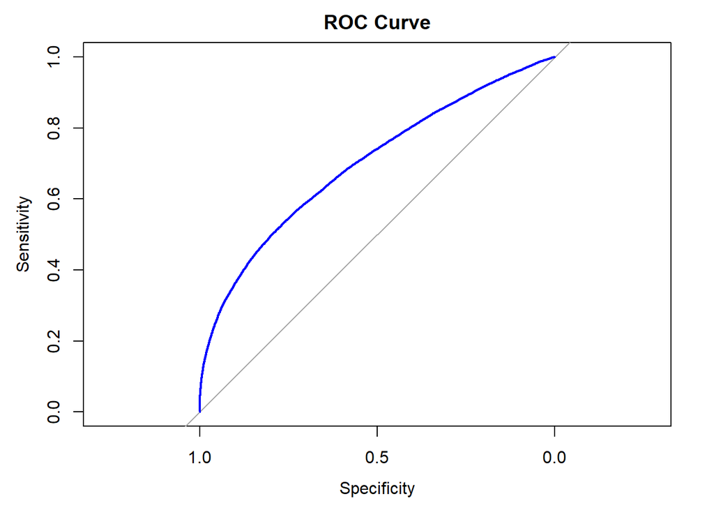

```r
predicted_probs <- predict(logit_model, newdata = X_test, type = "prob")
roc_curve <- roc(y_test, predicted_probs[,"True"])
plot(roc_curve, col = "blue", main = "ROC Curve")
```

Features importance analysis

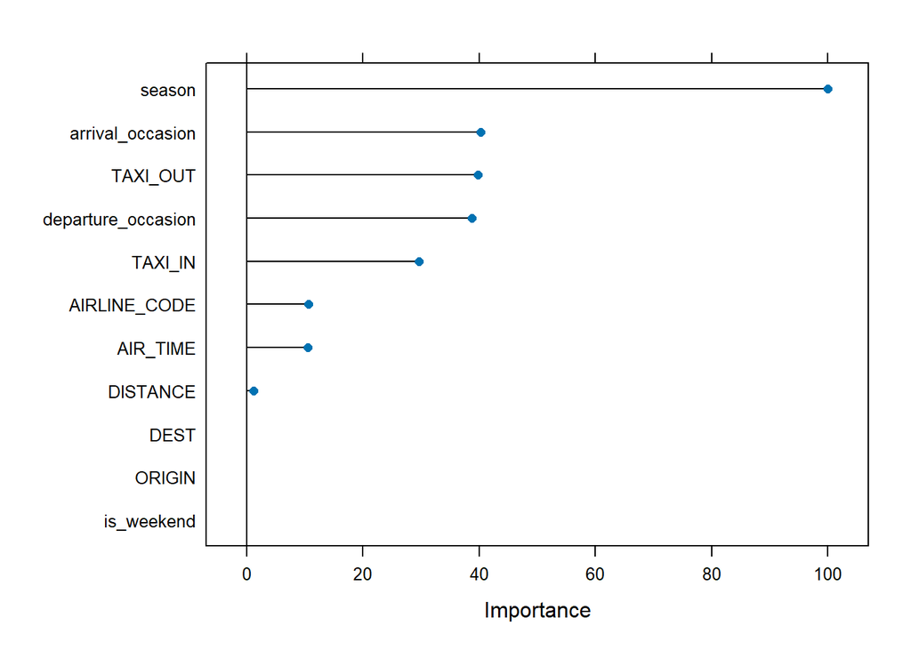

```r
plot(varImp(logit_model))
```

#### Using Random Forest

Cross-validation and the tuning grid

```r
rf_grid <- expand.grid(
  mtry = c(2, 3, 4, 5),
  splitrule = c("gini", "extratrees"),
  min.node.size = c(1, 5, 10)
)
```

Training on subset

```r
X_train_subset <- X_train[1:10000, ]
y_train_subset <- y_train[1:10000]

set.seed(123)
rf_model <- train(
  x = X_train_subset,
  y = as.factor(y_train_subset),
  method = "ranger",
  trControl = ctrl,
  tuneGrid = rf_grid,
  metric = "ROC"
)
```

Performance

```r
print(rf_model)
```

```
## Random Forest
##
## 10000 samples
##    11 predictor
##     2 classes: 'False', 'True'
##
## No pre-processing
## Resampling: Cross-Validated (10 fold)
## Summary of sample sizes: 8999, 9000, 9001, 9000, 9000, 9000, ...
## Resampling results across tuning parameters:
##
##   mtry  splitrule   min.node.size  ROC        Sens       Spec
##   2     gini         1             0.7212366  0.9085898  0.3383295
##   2     gini         5             0.7239437  0.9108346  0.3335129
##   2     gini        10             0.7256045  0.9121799  0.3335065
##   2     extratrees   1             0.7116618  0.9430014  0.2581262
##   2     extratrees   5             0.7173215  0.9495822  0.2445592
##   2     extratrees  10             0.7214667  0.9563143  0.2358106
##   3     gini         1             0.7182932  0.8978176  0.3482838
##   3     gini         5             0.7199852  0.9009604  0.3476859
##   3     gini        10             0.7248800  0.9055984  0.3467796
##   3     extratrees   1             0.7097362  0.9211584  0.3072908
##   3     extratrees   5             0.7160517  0.9250490  0.2970280
##   3     extratrees  10             0.7209275  0.9349225  0.2903915
##   4     gini         1             0.7190317  0.8963217  0.3549194
##   4     gini         5             0.7193025  0.8985688  0.3531040
##   4     gini        10             0.7217070  0.9002108  0.3497962
##   4     extratrees   1             0.7110927  0.9120327  0.3280876
##   4     extratrees   5             0.7160858  0.9151737  0.3208487
##   4     extratrees  10             0.7215561  0.9217551  0.3145215
##   5     gini         1             0.7156704  0.8934783  0.3570360
##   5     gini         5             0.7189702  0.8958722  0.3597478
##   5     gini        10             0.7205473  0.8987147  0.3567275
##   5     extratrees   1             0.7104426  0.9049994  0.3347232
##   5     extratrees   5             0.7145802  0.9109825  0.3329141
##   5     extratrees  10             0.7204499  0.9157705  0.3317084
##
## ROC was used to select the optimal model using the largest value.
## The final values used for the model were mtry = 2, splitrule = gini
##  and min.node.size = 10.
```

Confusion Matrix

```r
predictions <- predict(rf_model, newdata = X_test)
probabilities <- predict(rf_model, newdata = X_test, type = "prob")

y_test <- factor(y_test, levels = levels(predictions))
conf_matrix <- confusionMatrix(predictions, y_test, positive = "True")
print(conf_matrix)
```

```
## Confusion Matrix and Statistics
##
##           Reference
## Prediction False  True
##      False 36344 12729
##      True   3430  7092
##
##                Accuracy : 0.7289
##                  95% CI : (0.7253, 0.7324)
##     No Information Rate : 0.6674
##     P-Value [Acc > NIR] : < 2.2e-16
##
##                   Kappa : 0.3078
##
##  Mcnemar's Test P-Value : < 2.2e-16
##
##             Sensitivity : 0.3578
##             Specificity : 0.9138
##          Pos Pred Value : 0.6740
##          Neg Pred Value : 0.7406
##              Prevalence : 0.3326
##          Detection Rate : 0.1190
##    Detection Prevalence : 0.1766
##       Balanced Accuracy : 0.6358
##
##        'Positive' Class : True
##
```

ROC Curve

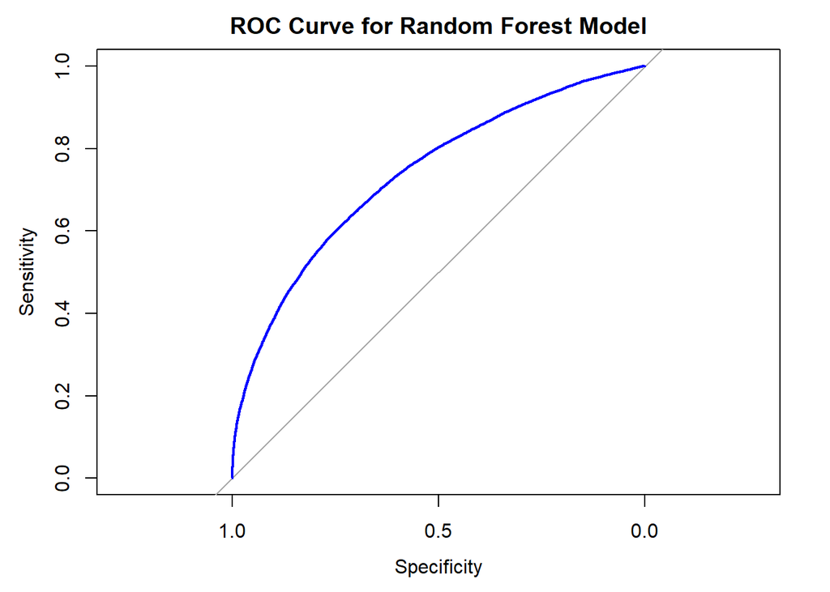

```r
roc_curve <- roc(y_test, probabilities$True)
plot(roc_curve, main = "ROC Curve for Random Forest Model", col = "blue")
```

#### Using XGBoost

Grid for tuning

```r
xgb_grid <- expand.grid(
  nrounds = c(50),
  max_depth = c(3, 5),
  eta = c(0.01, 0.1),
  gamma = c(0, 1),
  colsample_bytree = c(0.5, 0.7),
  min_child_weight = c(1, 3),
  subsample = c(0.7)
)

set.seed(123)
xgb_model <- train(
  x = as.matrix(X_train_subset),
  y = as.factor(y_train_subset),
  method = "xgbTree",
  trControl = ctrl,
  tuneGrid = xgb_grid,
  metric = "ROC"
)
```

Performance

```r
print(xgb_model)
```

```
## eXtreme Gradient Boosting
##
## 10000 samples
##    11 predictor
##     2 classes: 'False', 'True'
##
## No pre-processing
## Resampling: Cross-Validated (10 fold)
## Summary of sample sizes: 8999, 9000, 9001, 9000, 9000, 9000, ...
## Resampling results across tuning parameters:
##
##   eta   max_depth  gamma  colsample_bytree  min_child_weight  ROC
##   0.01  3          0      0.5               1                 0.7071493
##   0.01  3          0      0.5               3                 0.7090174
##   0.01  3          0      0.7               1                 0.7032865
##   0.01  3          0      0.7               3                 0.7037293
##   0.01  3          1      0.5               1                 0.7080986
##   0.01  3          1      0.5               3                 0.7078820
##   0.01  3          1      0.7               1                 0.7057698
##   0.01  3          1      0.7               3                 0.7039075
##   0.01  5          0      0.5               1                 0.7220410
##   0.01  5          0      0.5               3                 0.7199742
##   0.01  5          0      0.7               1                 0.7163545
##   0.01  5          0      0.7               3                 0.7160859
##   0.01  5          1      0.5               1                 0.7202982
##   0.01  5          1      0.5               3                 0.7195362
##   0.01  5          1      0.7               1                 0.7171638
##   0.01  5          1      0.7               3                 0.7186659
##   0.10  3          0      0.5               1                 0.7301274
##   0.10  3          0      0.5               3                 0.7296565
##   0.10  3          0      0.7               1                 0.7285732
##   0.10  3          0      0.7               3                 0.7284194
##   0.10  3          1      0.5               1                 0.7292405
##   0.10  3          1      0.5               3                 0.7287056
##   0.10  3          1      0.7               1                 0.7277180
##   0.10  3          1      0.7               3                 0.7285655
##   0.10  5          0      0.5               1                 0.7370265
##   0.10  5          0      0.5               3                 0.7357418
##   0.10  5          0      0.7               1                 0.7333828
##   0.10  5          0      0.7               3                 0.7373870
```

[output cut: 30 more lines]

```
##   0.9343215  0.3145097
##   0.9277394  0.3256679
##   0.9271370  0.3304927
##   0.9352184  0.3181333
##   0.9355157  0.3154224
##   0.9331241  0.3295891
##   0.9295329  0.3310978
##
## Tuning parameter 'nrounds' was held constant at a value of 50
## Tuning
##  parameter 'subsample' was held constant at a value of 0.7
## ROC was used to select the optimal model using the largest value.
## The final values used for the model were nrounds = 50, max_depth = 5, eta
##  = 0.1, gamma = 1, colsample_bytree = 0.7, min_child_weight = 1 and subsample
##  = 0.7.
```

Predictions

```r
predictions <- predict(xgb_model, newdata = as.matrix(X_test))
probabilities <- predict(xgb_model, newdata = as.matrix(X_test), type = "prob")
```

Confusion Matrix

```r
conf_matrix <- confusionMatrix(predictions, y_test, positive = "True")
print(conf_matrix)
```

```
## Confusion Matrix and Statistics
##
##           Reference
## Prediction False  True
##      False 36891 12992
##      True   2883  6829
##
##                Accuracy : 0.7336
##                  95% CI : (0.73, 0.7372)
##     No Information Rate : 0.6674
##     P-Value [Acc > NIR] : < 2.2e-16
##
##                   Kappa : 0.312
##
##  Mcnemar's Test P-Value : < 2.2e-16
##
##             Sensitivity : 0.3445
##             Specificity : 0.9275
##          Pos Pred Value : 0.7032
##          Neg Pred Value : 0.7396
##              Prevalence : 0.3326
##          Detection Rate : 0.1146
##    Detection Prevalence : 0.1630
##       Balanced Accuracy : 0.6360
##
##        'Positive' Class : True
##
```

ROC curve

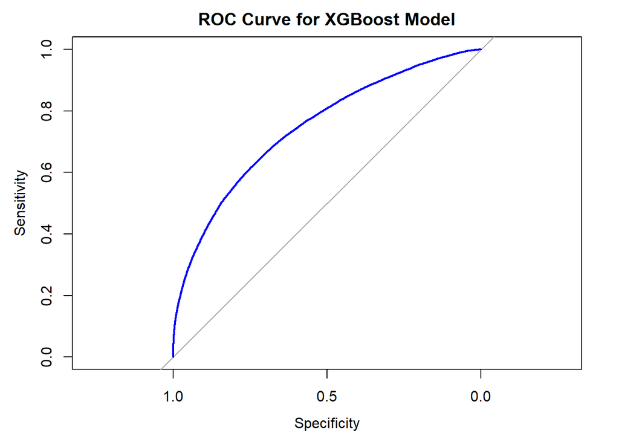

```r
roc_curve <- roc(y_test, probabilities$True)
plot(roc_curve, main = "ROC Curve for XGBoost Model", col = "blue")
```

AUC calculation

```r
auc_value <- auc(roc_curve)
print(auc_value)
```

```
## Area under the curve: 0.7467
```

Feature importance

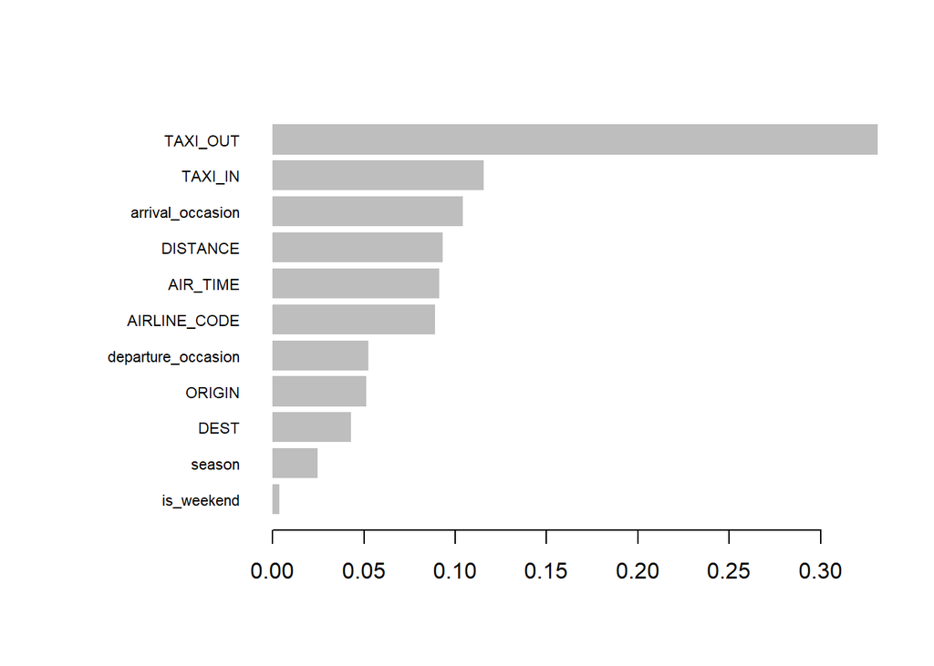

```r
importance <- xgb.importance(feature_names = colnames(X_train), model = xgb_model$finalModel)
xgb.plot.importance(importance)
```

#### Unseen data predictions

Data preparation

```r
training_flight_data_copy <- training_flight_data
columns_to_encode <- c("AIRLINE_CODE", "ORIGIN", "DEST", "is_weekend",
                       "season", "departure_occasion", "arrival_occasion")

for (col in columns_to_encode) {
  training_flight_data_copy[[col]] <- factor(training_flight_data_copy[[col]])
}

unseen_data <- data.frame(
  AIRLINE_CODE = factor("AA", levels = levels(training_flight_data_copy$AIRLINE_CODE)),
  ORIGIN = factor("JFK", levels = levels(training_flight_data_copy$ORIGIN)),
  DEST = factor("CAE", levels = levels(training_flight_data_copy$DEST)),
  TAXI_IN = 10,
  TAXI_OUT = 15,
  AIR_TIME = 300,
  DISTANCE = 2500,
  is_weekend = factor(TRUE, levels = levels(training_flight_data_copy$is_weekend)),
  season = factor("summer_holidays", levels = levels(training_flight_data_copy$season)),
  departure_occasion = factor("Late Afternoon", levels = levels(training_flight_data_copy$departure_occasion)),
  arrival_occasion = factor("Night", levels = levels(training_flight_data_copy$arrival_occasion))
)

for (col in columns_to_encode) {
  unseen_data[[col]] <- factor(unseen_data[[col]], levels = levels(training_flight_data_copy[[col]]))
  unseen_data[[col]] <- as.numeric(factor(unseen_data[[col]]))
}
```

Prediction Logistic Regression

```r
predict(logit_model, newdata = as.matrix(unseen_data), type = "prob")
```

| False | True |
| --- | --- |
| 0.8348843 | 0.1651157 |

Prediction Random Forest

```r
predict(rf_model, newdata = as.matrix(unseen_data), type = "prob")
```

| False | True |
| --- | --- |
| 0.5978845 | 0.4021155 |

Prediction XGBoost

```r
predict(xgb_model, newdata = as.matrix(unseen_data), type = "prob")
```

| False | True |
| --- | --- |
| 0.6184125 | 0.3815875 |